# Red drum broodstock offspring comparison

```r
knitr::opts_chunk$set(warning = FALSE, message = FALSE)
# # Install `SimRAD` and dependencies of not yet installed on server
#
# # Install BiocManager to install from Bioconductor
# if (!requireNamespace("BiocManager", quietly = TRUE))
#     install.packages("BiocManager")
#
# # Biostrings
# BiocManager::install("Biostrings")
#
# # ShortRead
# BiocManager::install("ShortRead")
#
# # zlibbioc
# BiocManager::install("zlibbioc")
#
# # SimRAD
# install.packages("SimRAD")
library(SimRAD)
# load libraries
source("scr/libraries.R")
# load functions
source("scr/ggplot.R")
source("scr/VCFfilterstats.R")
source("scr/HaplotypR.R")
source("scr/xtrafunctions.R")
source("scr/genind.R")
# other settings =====
# set how numbers are printed
options(scipen=999)
```

# Demultiplex sequences and Assess number of reads

## Estimate expected number of fragments and reads per individuals

### Estimate using probability of cut sites and fragment sizes

```r
# set enzyme parameters
EcoRI <- c("G", "A", "A", "T", "T", "C")
MspI <- c("C", "C", "G", "G")
GC <- 40
# set fragment parameters (tight window)
frag_min <- 338
frag_max <- 412
# set genome parameters
c <- 0.98 # from genomesize.com
# set desired coverage
cov_target <- 20
# set desired number of individuals per library/sequencing lane
nInd <- 240
# account for PhiX spike to use up certain number of reads
PhiX <- 10
```

```r
# calculate cut frequency for G and C
cutGC <- 0.5*(GC/100)
# calcuate cut frequency for A and T
cutAT <- 0.5*((100-GC)/100)
# cut frequency enzyme 1 (EcoRI) ----
# number of G/C in cut site
nGC <- as.numeric(sum(EcoRI == "G") + sum(EcoRI == "C"))
# number of A/T in cut site
nAT <- as.numeric(sum(EcoRI == "A") + sum(EcoRI == "T"))
frq1 <- cutGC^nGC*cutAT^nAT
# cut frequency enzyme 2 (MspI) ----
# number of G/C in cut site
nGC <- as.numeric(sum(MspI == "G") + sum(MspI == "C"))
# number of A/T in cut site
nAT <- as.numeric(sum(MspI == "A") + sum(MspI == "T"))
frq2 <- cutGC^nGC*cutAT^nAT
# frequency both enzyme cuts given the width of the selection window ----
frq3 <- frq1*frq2*(frag_max-frag_min)
```

The reciprocal indicate every how many base pairs the enzyme can be expected to cut, i.e. on average EcoRI will cut every 3086.4197531 and MspI every 625 bases. The frequency of getting fragments with both cut sites is the product of the two frequencies, which needs to be multiplied with the width of the selection window (wider window should select more fragments), i.e. for a ddRAD protocol using EcoRI and MsPI and we should get a fragment in the selection window of 338 - 412bp (74 bp wide) of 26067.7344011 bp.

The expected genome size can be calculated based on a c-value for a genome, e.g. for red drum (c-value = 0.98) the genome is expected to be 958.44 Mbp.

```r
# genome size
genome <- c*978
# expected number of cuts
cuts <- genome*1000000/(1/frq3)
# expected loci (if using only 1 enzyme would expect 2 loci per cut)
RADloc <- cuts*1
```

Leading to an expected number of 36767.291904 RAD loci per individual. For a targeted coverage of 20 reads per locus, a total of 0.7353458 Million reads are needed per individual.

```r
perInd <- RADloc*cov_target
```

Currently, one Illumina HiSeq 4000 lane produces approx. 300 Million reads, 10% reads are budgeted for PhiX spike in to diversify nucleotides for better results.

```r
tot_reads <- 300000000
PhiX_reads <- 300000000*.1
reads_per_ind <- (tot_reads-PhiX_reads)/nInd
```

The for 240 individuals being sequencin on a lane as a pooled library the expected number of reads per individuals is 1.125 Million.

### Estimate expected number of fragments using in silico digestions of genome

`SimRAD` will perform in silico digestions & size selection for simulated and sequenced reference genomes to estimate the expected number of fragments per individual.

#### Simulated genome for digestion & fragment selection

```r
# simulate genome
DNAseq <- sim.DNAseq(size = genome*1000000, GC = 0.4)

# define cut sites
EcoR1_5p1 <- "G"     # 5' side of cut site
EcoR1_3p1 <- "AATTC" # 3' side of cut site

MspI_5p2 <- "C"      # 5' side of cut site
MspI_3p2 <-"CGG"     # 3' side of cut site

# digest simulated genome
Sim <- insilico.digest(DNAseq, EcoR1_5p1, EcoR1_3p1, MspI_5p2, MspI_3p2, verbose = TRUE)
```

Select fragments with both cut sites, and determine number of fragments between 338 and 412.

```r
# select fragments w/both cut sites
AS <- adapt.select(Sim, type="AB+BA", EcoR1_5p1, EcoR1_3p1, MspI_5p2, MspI_3p2)

# size select
size_select <-size.select(AS, min.size = frag_min, max.size = frag_max, graph = TRUE, verbose = FALSE)
```

#### Use reference genome for red drum

Import sequenced red drum genome and digest using EcoRI and MsPI.

```r
# simulate genome
DNAseq <- ref.DNAseq("data/REF/soc_v1.fasta", subselect.contigs = FALSE)

# digest simulated genome
Sim <- insilico.digest(DNAseq, EcoR1_5p1, EcoR1_3p1, MspI_5p2, MspI_3p2, verbose = TRUE)
```

Select fragments with both cut sites and select fragments between 338 and 412bp length.

```r
# select fragments w/both cut sites
AS <-adapt.select(Sim, type="AB+BA", EcoR1_5p1, EcoR1_3p1, MspI_5p2, MspI_3p2)

# size select
size_select <-size.select(AS, min.size = frag_min, max.size = frag_max, graph = TRUE, verbose = FALSE)
```

Currently, one Illumina HiSeq 4000 lane produces approx. 300 Million reads, 10% reads are budgeted for PhiX spike in to diversify nucleotides for better results.

```r
tot_reads <- 300000000

PhiX_reads <- 300000000*.1

reads_per_ind <- (tot_reads-PhiX_reads)/nInd
```

Resulting in 1125000 reads per individual (240 individuals in a lane), over 7,975 loci this would mean a 141.0658307 coverage.

## Demultiplex samples

### Demultiplex Soc1

Make sure index is in the file name of the downloaded sequences before demultiplexing; input file barcode then index; `demultiplex.txt` is in UNIX format.

### Demultiplex Soc2

Make sure index is in the file name of the downloaded sequences before demultiplexing; input file barcode then index; `demultiplex.txt` is in UNIX format.

### Demultiplex Soc3

Make sure index is in the file name of the downloaded sequences before demultiplexing; input file barcode then index; `demultiplex.txt` is in UNIX format.

### Demultiplex Soc4

Make sure index is in the file name of the downloaded sequences before demultiplexing; input file barcode then index; `demultiplex.txt` is in UNIX format.

### Demultiplex Soc5

Make sure index is in the file name of the downloaded sequences before demultiplexing; input file barcode then index; `demultiplex.txt` is in UNIX format.

### Demultiplex SocX1

Make sure index is in the file name of the downloaded sequences before demultiplexing; input file barcode then index; `demultiplex.txt` is in UNIX format.

### Demultiplex SocX2

Make sure index is in the file name of the downloaded sequences before demultiplexing; input file barcode then index; `demultiplex.txt` is in UNIX format.

## Quality control demultiplexed reads

### Assess number of reads per individuals

Parse process radtags log file.

```r
# IMPORT BARCODE & INDEX FOR EACH SAMPLE USING DEMULTIPLEX FILES ----
# all demultiplex files named Demultiplex_SP-COD-LibNo.txt
# list all demultiplex files
d <- list.files(path = "data/SEQ", pattern = "Demultiplex*")
# directory with demultiplex files
dir <- "data/SEQ"
# create empty list
barcodes <- list()

# import all demultiplex files
for (i in 1:length(d)){

  lib <- d[[i]] %>%
    str_sub(13, -5) %>%
    sub(pattern = "-", replacement = "")

  f <- file.path(dir, d[[i]])

  barcodes[[i]] <- read_delim(f, delim = "\t", col_names = c("SAMPLE", "BARCODE", "INDEX")) %>%
    mutate(LIBRARY = lib)
}
# create single data frame
barcodes <- ldply(barcodes, data.frame)
# IMPORT READS PER SAMPLE USING PROCESS RADTAGS LOG FILES ----
# all logs named LIBCODE_INDEX_radtags.log
# directory with radtag logs
dir <- "data/SEQ"
# list all radtag logs
logs <- list.files(path = "data/SEQ", pattern = "*radtags.log")
# create empty list
l <- list()
# number of samples in each index
n_samples <- 48
# read in your logs
for (i in 1:length(logs)){

  f <- file.path(dir, logs[[i]])

  name <- logs[[i]] %>%
    str_split_fixed(pattern = "_", n = 3)

  index <- name[[2]]
  lib <- name[[1]]

  demultiplex <- barcodes %>%
    filter(LIBRARY == lib) %>%
    select(-LIBRARY)

  l[[i]] <- read_table2(f,
                        skip = 13, n_max = n_samples,
                        col_names = c("BARCODE", "TOTAL_READS", "AMBIG_READS", "LQ_READS", "RETAINED")) %>%
        mutate(PROP_RETAINED = RETAINED/TOTAL_READS,
               INDEX = index,
               LIBRARY = lib) %>%
        select(LIBRARY, INDEX, BARCODE, PROP_RETAINED, TOTAL_READS, RETAINED, AMBIG_READS, LQ_READS) %>%
        left_join(demultiplex)

}
# create single data frame
radtagslog <- ldply(l, data.frame) %>%
  select(-LQ_READS) %>%
  unite(LIB_IDX, LIBRARY, INDEX, sep = "_", remove = FALSE)
write_delim(radtagslog, "results/all.radtags.log")
```

Compare demultiplexed reads per library & index.

Plot distributions of total and proportion of retained reads.

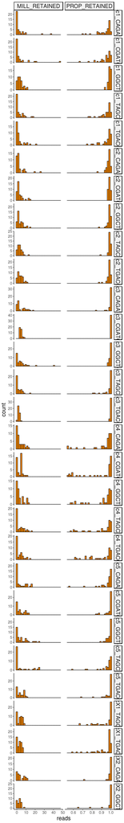

```r
radtagslog %>%
  filter(!str_detect(SAMPLE, 'BLANK')) %>%
  mutate(MILL_RETAINED = RETAINED/1000000) %>%
  select(LIB_IDX, LIBRARY, INDEX, BARCODE, PROP_RETAINED, MILL_RETAINED) %>%
  gather(key = STAT, value = READS, 5:6) %>%
  ggplot(aes(x = READS)) +
  geom_histogram(color = "black", fill = "darkorange") +
  labs(x = "reads") +
  facet_grid(LIB_IDX ~ STAT, scales = "free") +
  theme_standard
```

Assess relationship between proportion and number of reads retained.

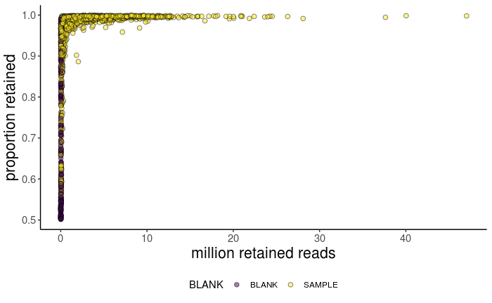

```r
radtagslog %>%
  mutate(BLANK = ifelse(str_detect(SAMPLE, 'BLANK'), "BLANK", "SAMPLE"),
         MILL_RETAINED = RETAINED/1000000) %>%
  ggplot() +
  geom_point(aes(x = MILL_RETAINED, y = PROP_RETAINED, fill = BLANK),
             shape = 21, color = "black", alpha = 0.5, size = 2) +
  scale_fill_viridis_d() +
  labs(x = "million retained reads", y = "proportion retained") +
  theme_standard
```

Compare number of reads per sample

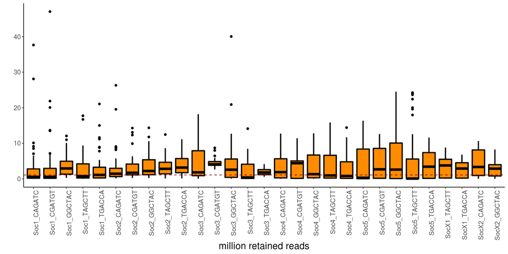

```r
# remove blanks from samples before plotting
radtagslog %>%
  filter(!str_detect(SAMPLE, 'BLANK')) %>%
  mutate(MILL_RETAINED = RETAINED/1000000) %>%
  ggplot() +
  geom_boxplot(aes(y = MILL_RETAINED, x = LIB_IDX), color = "black", fill = "darkorange", size = 1) +
  geom_hline(yintercept = 1.1, color = "darkred", linetype = "dashed") +
  labs(x = "million retained reads", y = "") +
  theme_standard +
  theme(axis.text.x = element_text(angle = 90, hjust = 1))
```

Count number of samples with > 1,000,000 reads:

```r
radtagslog %>%
  filter(!str_detect(SAMPLE, 'BLANK')) %>%
  group_by(LIB_IDX) %>%
  count(RETAINED > 1000000) %>%
  spread(key = `RETAINED > 1000000`, value = n)
```

| LIB_IDX | FALSE | TRUE |
| --- | --- | --- |
| Soc1_CAGATC | 25 | 15 |
| Soc1_CGATGT | 24 | 16 |
| Soc1_GGCTAC | 9 | 33 |
| Soc1_TAGCTT | 24 | 16 |
| Soc1_TGACCA | 20 | 20 |
| Soc2_CAGATC | 16 | 23 |
| Soc2_CGATGT | 9 | 31 |
| Soc2_GGCTAC | 7 | 35 |
| Soc2_TAGCTT | 6 | 34 |
| Soc2_TGACCA | 5 | 35 |

[output cut: 19 more lines]

```r
radtagslog %>%
  filter(!str_detect(SAMPLE, 'BLANK')) %>%
  count(RETAINED > 1000000)
```

| RETAINED > 1000000 | n |
| --- | --- |
| FALSE | 429 |
| TRUE | 728 |

Quantiles of retained reads per sample (without blanks)

```r
temp <- radtagslog %>%
  filter(!str_detect(SAMPLE, 'BLANK'))
quantile(temp$RETAINED, probs = c(0.001, 0.01, 0.05, 0.10, 0.33, 0.5))
```

```
       0.1%          1%          5%         10%         33%         50%
   8479.988   16850.280   36803.400   69398.200  719083.640 2066268.000
```

## Quality trim

### Remove low quality individuals

To cut down on computational power blanks and individuals with very low number of reads can be removed.

Identify low quality individuals.

```r
lq_ind <- radtagslog %>%
  filter(!str_detect(SAMPLE, 'BLANK')) %>%
  filter(RETAINED < 50000 & PROP_RETAINED < 0.7)
blanks <- radtagslog %>%
  filter(str_detect(SAMPLE, 'BLANK'))
```

Write bash script to delete `fastq` files of low quality individuals from Soc-1.

```r
command <- "rm"
SEQ <- rm_ind %>%
  select(SAMPLE) %>%
  mutate(temp = "*") %>%
  unite(SEQ, SAMPLE, temp, sep = "") %>%
  mutate(COMMAND = command) %>%
  select(COMMAND, SEQ)
write.table(SEQ, "scr/rm_LQind.sh",
            col.names = FALSE, quote = FALSE, row.names = FALSE)
```

Remove files

```bash
# make executable
chmod 755 /home/soleary/DRUM/scr/rm_LQind.sh

# go to sequences parent directory
cd /home/soleary/DRUM/data/SEQ/

# loop over all reference creation folders
for d in Soc*

do
    (cd "$d" && sh /home/soleary/DRUM/scr/rm_LQind.sh)

done
```

### Quality trim data

`dDocent` uses Trimmomatic to quality trim the data - this only needs to occur once. Low quality bases (< 20) are trimmed from beginning/end of reads. Additionally, bases are trimmed when average quality drops below 5 in a sliding window (5bp). The quality trimmed files are needed for further steps in `dDocent` (`*.R1.fq` and `*.R2.fq`)

Run `dDocent` in each sequence folder to quality trim reads.